# Week 4 Model Performance Evaluation

## Theory and Practice

### by Ying Lin, Ph.D.

## Overview of Topics

- Why we need an unbiased estimate of *TRUE* model performance
- Methods to evaluate model performance
- Metrics for classification model performance
- Additional metrics for regression models
- Python demo of model performance evaluation

## Overfitting

- Training accuracy vs.testing accuracy

[figure not shown]

- Why neither training accuracy nor test accuracy is not good enough?

## Model Evaluation Methods (1)

- Unbiased methods
  - Hold-out method: createDataPartition()
  - Cross-validation method: createFolds()
  - Leave one out (Jackknife method)
  - Bootstrapping: createResample()
  - All of the above methods are implemented in *sklearn* cross_validation module
- factors of comparison between different methods
  - Speed
  - Variability/reliability

## Model Evaluation Methods (2)

[figure not shown]

## Model Evaluation vs. Model Tuning

- Purpose of model performance evaluation
  - Get unbiased estimate of *TRUE* performance when the model is applied towards *unseen* data
  - Provide feedback for model hyperparameter tuning
- Model evaluation is not part of model hyperparameter tuning
  - if you get a better performance through one evaluation method, it doesn't mean the model is better
  - don't merely change evaluation method parameters in order to get a better model (same underlying models)

## Confusion Matrix

- Confusion/contingency table

| Table | Predicted Positive | Predicted Negative |
| --- | --- | --- |
| Actual Positive | True Positive (TP) | False Negative (FN) |
| Actual Negative | False Positive (FP) | True Negative (TN) |

- Accuracy: percent of the predictions that are correct  
  $Accuracy = \frac{TP + TN}{TP + FP + FN + TN}$

## Model Performance Metrics

- Accuracy
- Special challenges: imbalanced data
- Confusion matrix derived metrics
  - TP, FP, FN, TN,
    - FP (Type I error) vs. FN (Type II error)
    - Which type of error is worse: medical diagnostic, SPAM detection, criminal justice system, fraudence detection, etc.
  - Kappa Statistics
  - Precision vs. recall
  - F measure
  - Sensitivity vs. specificity

## Kappa Statistics

- Kappa (**$\kappa$**): measures inter-rater aggreement (or reliability) for qualitative (categorical) items.
  - $\kappa = \frac{p_o-p_e}{1-p_e}$
    - $p_o$: observed agreement among raters
    - $p_e$: hypothetical probability of chance agreement
- It is more robust by considering the possibility of the agreement occurring by chance.
  - Range: [0, 1]
  - 0 = agreement equivalent to chance; 1 = perfect agreement

## Precision, Recall and F-measure (1)

- Originates from information retrieval. Derived for each of possible class labels. such as Precision(Class = "Churn"), or Recall(Class = "Not Churn") or F(Class = "Churn")
- Precision (positive predictive value): percent of predicted positive that are correct (in IR context, fraction of relevant instances among the retrieved instances) $Precision = \frac{TP}{TP + FP}$
- Recall (sensitivity): percent of positive cases that are correctly predicted (in IR context, fraction of the relevant documents that are successfully retrieved) $Recall = \frac{TP}{TP + FN}$

## Precision, Recall and F-measure (2)

- F-measure (F1 or F score):
  - Balance between precision and recall (Harmonic Mean)
    - Harmonic mean is closer to the smaller value when precision and recall are different
    - Why? Example: naive classifier for a perfectly balanced dataset predicts all data points in one class, precision/recall/arithmetic mean/harmonic mean?
  - Range between 0 and 1 (perfect precision and recall) $F measure = \frac{2 * Precision * Recall}{Precision + Recall}$

## Sensitivity vs. Specificity

- Often used in medical dignostic testings or screening study which have positive vs. negative testing results
- Sensitivity (True Positive Rate or TPR, or recall): Percent of positive cases correctly predicted, or coverage of actual positive cases
- Specificity (True Negative Rate or TNR): Percent of negative cases correctly predicted, or coverage of actual negative cases
- How does the pair of sensitivity and specificity cope with imbalanced data?

[figure not shown]

## Receiver Characteristic Curve (ROC)

- ROC plots Sensitivity vs. (1 - Specificity) or TPR vs. FPR
- Area Under Curve (AUC)
- ROC/AUC measure the model's ability to distingush between the classes
  - based on the model's predicted probability for target positive class label
  - inputs to ROC function: (Predicted Probability for Target Label, Target Label)

[figure not shown]

## Additional Model Performance Metrics

- Loss functions
- Classification
  - Log Loss or Cross Entropy
  - Hinge loss
- Regression
  - $R^2$
  - Sum of Squared Error (SSE) and its variants (MSE, RMSE, etc.)
  - Mean Absolute Error (MAE)

## Notes about Sklearn

- All the attributes need to be numerical
- There can't be missing values; otherwise fit() will return ValueError

```python
## Decision Tree Modeling in Python

import pandas as pd
import numpy as np
from sklearn.tree import DecisionTreeClassifier
from sklearn.model_selection import train_test_split, GridSearchCV, cross_val_score, cross_validate, ShuffleSplit, LeaveOneOut
from sklearn import metrics
from matplotlib import pyplot as plt
np.random.seed(66)

churn = pd.read_csv('https://raw.githubusercontent.com/yhat/demo-churn-pred/master/model/churn.csv')
churn["Int'l Plan"] = churn["Int'l Plan"].map(dict(yes=1, no=0))
churn['VMail Plan'] = churn['VMail Plan'].replace({"yes": 1, "no": 0})
churn.select_dtypes('object').columns
```

```
Index(['State', 'Phone', 'Churn?'], dtype='object')
```

```
DecisionTreeClassifier(ccp_alpha=0.0, class_weight=None, criterion='gini',
                       max_depth=None, max_features=None, max_leaf_nodes=None,
                       min_impurity_decrease=0.0, min_impurity_split=None,
                       min_samples_leaf=1, min_samples_split=2,
                       min_weight_fraction_leaf=0.0, presort='deprecated',
                       random_state=None, splitter='best')
```

[output not shown]

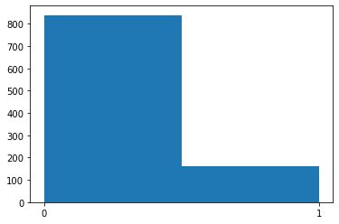

```python
## Model Training/Testing

num_vars = churn.select_dtypes('number').columns
X = churn[num_vars]
y = churn['Churn?'].map({'True.': 1, 'False.': 0})

X_train, X_test, y_train, y_test = train_test_split(X, y, test_size=0.3, random_state=16)
clf = DecisionTreeClassifier()
clf.fit(X_train, y_train)
y_pred = clf.predict(X_test)

plt.hist(y_pred, bins=2)
plt.xticks(range(0, 2))
plt.show()
```

```python
## Performance Reporting

print(f"Accuracy: {round(metrics.accuracy_score(y_test, y_pred)*100, 2)}%")
df_confusion = pd.crosstab(y_test, y_pred)
df_confusion.index = [['Real', 'Real'], ['Stay', 'Leave']]
df_confusion.columns = [['Predict'] * 2, ['Stay', 'Leave']]
df_confusion
print(metrics.classification_report(y_test, y_pred))
```

```
Accuracy: 90.1%
```

|  |  | Predict Stay | Predict Leave |
| --- | --- | --- | --- |
| Real | Stay | 788 | 48 |
|  | Leave | 51 | 113 |

```
              precision    recall  f1-score   support

           0       0.94      0.94      0.94       836
           1       0.70      0.69      0.70       164

    accuracy                           0.90      1000
   macro avg       0.82      0.82      0.82      1000
weighted avg       0.90      0.90      0.90      1000
```

```python
## Hyperparameters' Grid Search

param_grid = {'criterion': ['gini', 'entropy'],
              'min_samples_split': [2, 10, 20, 30],
              'max_depth': [4, 5, 6, 10, 15, 20],
              'min_samples_leaf': [ 1, 5, 10],
              'max_leaf_nodes': [2, 5, 10, 20]}
grid = GridSearchCV(clf, param_grid, cv=5)
grid.fit(X_train, y_train)
print(grid)
```

```
GridSearchCV(cv=5, error_score=nan,
             estimator=DecisionTreeClassifier(ccp_alpha=0.0, class_weight=None,
                                              criterion='gini', max_depth=None,
                                              max_features=None,
                                              max_leaf_nodes=None,
                                              min_impurity_decrease=0.0,
                                              min_impurity_split=None,
                                              min_samples_leaf=1,
                                              min_samples_split=2,
                                              min_weight_fraction_leaf=0.0,
                                              presort='deprecated',
                                              random_state=None,
                                              splitter='best'),
             iid='deprecated', n_jobs=None,
             param_grid={'criterion': ['gini', 'entropy'],
                         'max_depth': [4, 5, 6, 10, 15, 20],
                         'max_leaf_nodes': [2, 5, 10, 20],
                         'min_samples_leaf': [1, 5, 10],
                         'min_samples_split': [2, 10, 20, 30]},
             pre_dispatch='2*n_jobs', refit=True, return_train_score=False,
             scoring=None, verbose=0)
```

[output not shown]

```python
## Repeated Hold-Out Method

bstrap = ShuffleSplit(n_splits=10, test_size=0.3, random_state=16)
grid_bstrap = GridSearchCV(clf, param_grid, cv=bstrap)
grid_bstrap.fit(X_train, y_train)
```

```
GridSearchCV(cv=ShuffleSplit(n_splits=10, random_state=16, test_size=0.3, train_size=None),
             error_score=nan,
             estimator=DecisionTreeClassifier(ccp_alpha=0.0, class_weight=None,
                                              criterion='gini', max_depth=None,
                                              max_features=None,
                                              max_leaf_nodes=None,
                                              min_impurity_decrease=0.0,
                                              min_impurity_split=None,
                                              min_samples_leaf=1,
                                              min_samples_split=2,
                                              min_weight_fraction_leaf=0.0,
                                              presort='deprecated',
                                              random_state=None,
                                              splitter='best'),
             iid='deprecated', n_jobs=None,
             param_grid={'criterion': ['gini', 'entropy'],
                         'max_depth': [4, 5, 6, 10, 15, 20],
                         'max_leaf_nodes': [2, 5, 10, 20],
                         'min_samples_leaf': [1, 5, 10],
                         'min_samples_split': [2, 10, 20, 30]},
             pre_dispatch='2*n_jobs', refit=True, return_train_score=False,
             scoring=None, verbose=0)
```

```python
## Hyperparameters for Best Performinig Model

print(f"Accuracy: {round(grid_bstrap.best_score_*100, 2)}%")
for key, value in grid_bstrap.best_params_.items():
  print(f"Hyperparameter: {key}; Value: {value}")
```

```
Accuracy: 94.24%
Hyperparameter: criterion; Value: entropy
Hyperparameter: max_depth; Value: 15
Hyperparameter: max_leaf_nodes; Value: 20
Hyperparameter: min_samples_leaf; Value: 10
Hyperparameter: min_samples_split; Value: 2
```

```python
## Leave One Out

loocv = LeaveOneOut()
lv_score = cross_val_score(clf, X, y, cv=loocv)
print(f"Leave One Out accuracy is {round(lv_score.mean(), 2)}")
```

```
Leave One Out accuracy is 0.92
```

```
AUC = 0.8884350565993698
```

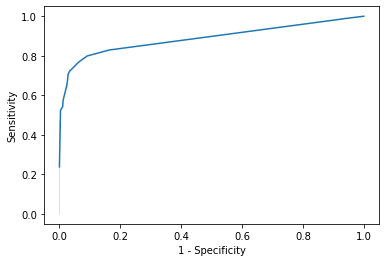

```python
from sklearn.metrics import roc_auc_score, roc_curve

y_pred_prob = grid.predict_proba(X_test)[:, 1]
auc = roc_auc_score(y_test, y_pred_prob)
print(f"AUC = {auc}")
fpr, tpr, _ = roc_curve(y_test, y_pred_prob)

import seaborn as sns
sns.lineplot(fpr, tpr)
plt.xlabel('1 - Specificity')
plt.ylabel('Sensitivity')
```